# Finding and preparing spatial data

```r
library(sf)
library(tidyverse)
library(ggspatial)
library(rnaturalearth)
```

# 1 Learning objectives

- Identify reliable sources for finding spatial data online
- Understand basic principles for evaluating data quality using metadata
- Make informed choices between common spatial data formats:
  - Shapefile
  - GeoJSON
  - GeoPackage
- Load vector spatial data from your own computer into R using `st_read()`
- Load simple tabular data using `read_csv()`
- Explain why working directories are crucial for loading files easily
- Perform basic data cleaning tasks on `sf` objects using `dplyr` functions
- Join tabular data to your spatial data based on a common identifier using `left_join`
- Save you cleaned spatial data to a file using `st_write()`

# 2 Concepts: Finding your ingredients and checking quality

## 2.1 Where to find spatial data: reliable sources

### 2.1.1 Natural earth

- Global datasets at various scales
- Public domain
- Might not have super-detailed local data

### 2.1.2 OpenStreetMap

- A collaborative project
- Amazingly detailed, often the most up-to-date source for features like roads/buildings, global coverage, free to use
- Data quality varies by region

### 2.1.3 GADM

- Database of Global ADministrative Areas
- Consistent source for administrative boundaries worldwide, differente levels of detail
- Boundaries might not perfectly match official national sources in every single case

### 2.1.4 Government geospatial portals

In the case of Colombia:

- [Colombia en mapas](https://www.colombiaenmapas.gov.co/)
  - Iniciar sesion > Iniciar sesión con Google
  - VI > [Ver a CeM v1](https://www.colombiaenmapas.gov.co/ndexv1.html)
    - Filtrar > Entidad Territorial > Colombia
    - Temáticas > Límites > Departamentos de Colombia
      - Formato de descargar: GDB (`.gdb`), Geopackage (`.gpkg`), Shapefile
      - Use Geopackage (it is highly recommended)

#### 2.1.4.1 Search strategy

- Need general world/country/state boundaries? Start with `rnaturalearth`
- Need detailed streets, buildings, cafes, parks? Start with `osmdata`
- need official local data? In the case of Colombia go to [Colombia en mapas](https://www.colombiaenmapas.gov.co/)

### 2.1.5 Is this data any good? Metadata and Quality Checks

- Source:
  - Who created the data?
  - Is the source trustworthy for your purpose

  **Answer**: For the case of Colombia was created by Instituto Geográfico Agustín Codazzi - IGAC, so it is trustworthy
- Date
  - When was created?
  - When was it las t updated
  - It is recent enough for your map?

  **Answer**: It was created in `2025-12-30` and it will be updated in `2026-02-05`
- Description/Abstract
  - What does this data actually represent?
  - What do the columns in the attribute table mean?
- CRS
  - What coordinate reference system does it use?
- Scale/Resolution
  - At what level of detail was it created?
- Accuracy:
  - Does the provider mention how accurate the locations or attributes are believed to be?
- Limitations/known issues:
  - Are there any problems the creator is aware of?
- LIcense/Use Contraints
  - How are you allowed to use this data?
  - Do you need to five credit?
  - Can you use it for commercial purposes?

  **Answer**: Licencia: CC BY 4.0

### 2.1.6 Choosing Data Formats

Simple rule: If available prefer GeoPackage `.gpkg`

### 2.1.7 Ethical considerations: Data SElection & Bias

- Source Bias:
  - Whose data is it?
  - Does the source have a perspective?
  - Does it represent all grouos/areas fairly?
- Representation:
  - Does the dataset accurately represent the phenomenom?
  - Are certain categories oversimplified? Does it exclude important groups?
- Privacy
  - Does the data contain potentially sensitive location information about individuals?

# 3 Hands-on: Loading and Cleaning Your Own data

## 3.1 Import

```r
depart_col <- st_read(
  dsn = "../000_data/colombia/departamentos-de-colombia_2025-12-30.gpkg"
)
mun_col <- st_read(
  dsn = "../000_data/colombia/municipios-de-colombia-2025-12-30.gpkg"
)

world_boundaries_loaded <- st_read(
  dsn = "../000_data/mapping-worlds-with-r/chapter-3/world_boundaries.gpkg"
)
country_indicators_loaded <- read_csv(
  file = "../000_data/mapping-worlds-with-r/chapter-3/country_indicators.csv"
)
```

## 3.2 CRS

```r
st_crs(depart_col)
```

```
Coordinate Reference System:
  User input: MAGNA-SIRGAS 2018 / Origen-Nacional
  wkt:
PROJCRS["MAGNA-SIRGAS 2018 / Origen-Nacional",
    BASEGEOGCRS["MAGNA-SIRGAS 2018",
        DATUM["Marco Geocentrico Nacional de Referencia 2018",
            ELLIPSOID["GRS 1980",6378137,298.257222101,
                LENGTHUNIT["metre",1]]],
        PRIMEM["Greenwich",0,
            ANGLEUNIT["degree",0.0174532925199433]],
        ID["EPSG",20046]],
    CONVERSION["Colombia Transverse Mercator",
        METHOD["Transverse Mercator",
            ID["EPSG",9807]],
        PARAMETER["Latitude of natural origin",4,
            ANGLEUNIT["degree",0.0174532925199433],
            ID["EPSG",8801]],
        PARAMETER["Longitude of natural origin",-73,
            ANGLEUNIT["degree",0.0174532925199433],
            ID["EPSG",8802]],
        PARAMETER["Scale factor at natural origin",0.9992,
            SCALEUNIT["unity",1],
            ID["EPSG",8805]],
        PARAMETER["False easting",5000000,
            LENGTHUNIT["metre",1],
            ID["EPSG",8806]],
        PARAMETER["False northing",2000000,
            LENGTHUNIT["metre",1],
            ID["EPSG",8807]]],
    CS[Cartesian,2],
        AXIS["northing (N)",north,
            ORDER[1],
            LENGTHUNIT["metre",1]],
        AXIS["easting (E)",east,
            ORDER[2],
            LENGTHUNIT["metre",1]],
    USAGE[
        SCOPE["Cadastre, topographic mapping."],
        AREA["Colombia - onshore and offshore. Includes San Andres y Providencia, Malpelo Islands, Roncador Bank, Serrana Bank and Serranilla Bank."],
        BBOX[-4.23,-84.77,15.51,-66.87]],
    ID["EPSG",9377]]
```

## 3.3 Visualization

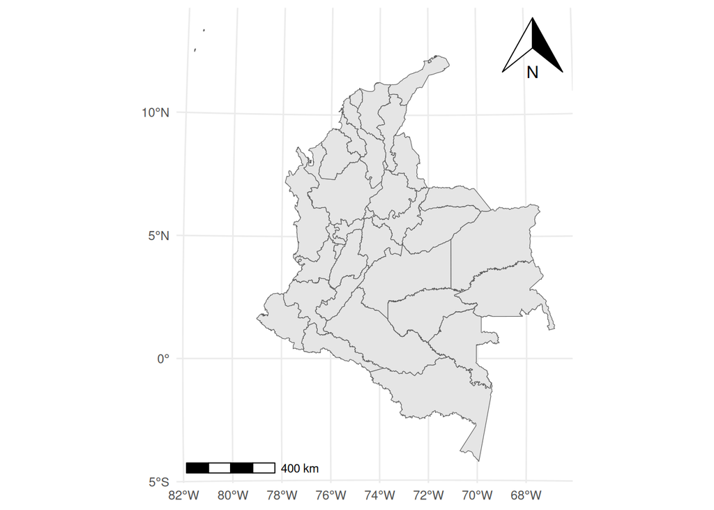

Figure 1: Colombian departments

```r
depart_col |>
  ggplot() +
  geom_sf(
    aes(geometry = SHAPE)
  ) +
  annotation_scale(
    location = "bl"
  ) +
  annotation_north_arrow(
    location = "tr"
  ) +
  coord_sf(datum = st_crs(x = 4626)) +
  theme_minimal()
```

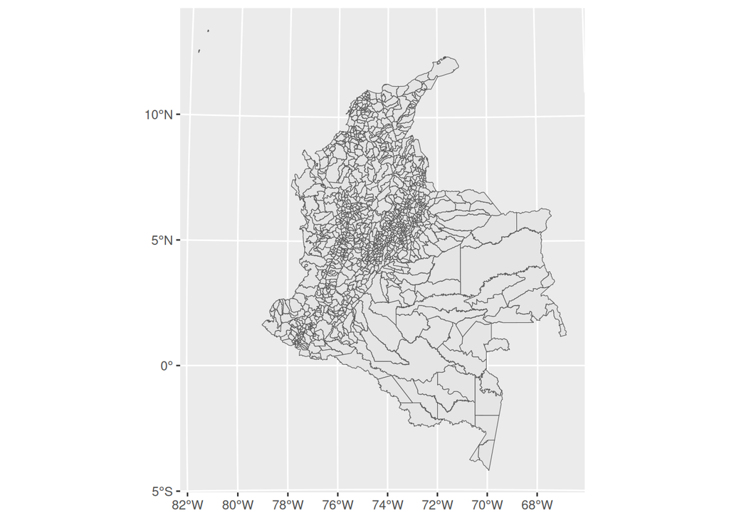

Figure 2: Colombian municipalities

```r
mun_col |>
  ggplot() +
  geom_sf(
    aes(geometry = SHAPE)
  )
```

## 3.4 Basic data cleaning with `dplyr`

### 3.4.1 Select and rename

```r
world_selected <- world_boundaries_loaded |>
  select(
    NAME_ENGL,
    ISO3_CODE,
    geom
  )

world_remaned <- world_selected |>
  rename(
    country_name = NAME_ENGL,
    iso3 = ISO3_CODE,
    geometry = geom
  )

world_ne <- ne_countries(
  scale = "medium",
  returnclass = "sf"
) |>
  select(
    adm0_a3,
    continent
  ) |>
  st_drop_geometry()
```

### 3.4.2 Join

```r
world_remaned_with_cont <- world_remaned |>
  left_join(
    y = world_ne,
    by = join_by(iso3 == adm0_a3)
  )

world_data_joined <- world_remaned |>
  left_join(
    y = country_indicators_loaded,
    by = join_by(iso3 == iso3c)
  )
```

### 3.4.3 Filter

```r
africa_only <- world_remaned_with_cont |>
  filter(continent == "Africa")
```

#### 3.4.3.1 Check if `geometry` is empty

```r
africa_only |>
  filter(st_is_empty(geometry))
```

```
Simple feature collection with 0 features and 3 fields
Geometry type: MULTIPOLYGON
Bounding box:  xmin: NA ymin: NA xmax: NA ymax: NA
Geodetic CRS:  WGS 84
[1] country_name iso3         continent    geometry
<0 rows> (or 0-length row.names)
```

```r
world_data_joined |>
  filter(st_is_empty(geometry))
```

```
Simple feature collection with 0 features and 8 fields
Geometry type: MULTIPOLYGON
Bounding box:  xmin: NA ymin: NA xmax: NA ymax: NA
Geodetic CRS:  WGS 84
[1] country_name    iso3            country         iso2c
[5] year            gdp_per_capita  life_expectancy population
[9] geometry
<0 rows> (or 0-length row.names)
```

#### 3.4.3.2 Check if `geometry` is valid

```r
africa_only |>
  st_is_valid()
```

```
 [1] TRUE TRUE TRUE TRUE TRUE TRUE TRUE TRUE TRUE TRUE TRUE TRUE TRUE TRUE TRUE
[16] TRUE TRUE TRUE TRUE TRUE TRUE TRUE TRUE TRUE TRUE TRUE TRUE TRUE TRUE TRUE
[31] TRUE TRUE TRUE TRUE TRUE TRUE TRUE TRUE TRUE TRUE TRUE TRUE TRUE TRUE TRUE
[46] TRUE TRUE TRUE TRUE TRUE TRUE
```

```r
world_data_joined |>
  st_is_valid()
```

```
  [1] TRUE TRUE TRUE TRUE TRUE TRUE TRUE TRUE TRUE TRUE TRUE TRUE TRUE TRUE TRUE
 [16] TRUE TRUE TRUE TRUE TRUE TRUE TRUE TRUE TRUE TRUE TRUE TRUE TRUE TRUE TRUE
 [31] TRUE TRUE TRUE TRUE TRUE TRUE TRUE TRUE TRUE TRUE TRUE TRUE TRUE TRUE TRUE
 [46] TRUE TRUE TRUE TRUE TRUE TRUE TRUE TRUE TRUE TRUE TRUE TRUE TRUE TRUE TRUE
 [61] TRUE TRUE TRUE TRUE TRUE TRUE TRUE TRUE TRUE TRUE TRUE TRUE TRUE TRUE TRUE
 [76] TRUE TRUE TRUE TRUE TRUE TRUE TRUE TRUE TRUE TRUE TRUE TRUE TRUE TRUE TRUE
 [91] TRUE TRUE TRUE TRUE TRUE TRUE TRUE TRUE TRUE TRUE TRUE TRUE TRUE TRUE TRUE
[106] TRUE TRUE TRUE TRUE TRUE TRUE TRUE TRUE TRUE TRUE TRUE TRUE TRUE TRUE TRUE
[121] TRUE TRUE TRUE TRUE TRUE TRUE TRUE TRUE TRUE TRUE TRUE TRUE TRUE TRUE TRUE
[136] TRUE TRUE TRUE TRUE TRUE TRUE TRUE TRUE TRUE TRUE TRUE TRUE TRUE TRUE TRUE
[151] TRUE TRUE TRUE TRUE TRUE TRUE TRUE TRUE TRUE TRUE TRUE TRUE TRUE TRUE TRUE
[166] TRUE TRUE TRUE TRUE TRUE TRUE TRUE TRUE TRUE TRUE TRUE TRUE TRUE TRUE TRUE
[181] TRUE TRUE TRUE TRUE TRUE TRUE TRUE TRUE TRUE TRUE TRUE TRUE TRUE TRUE TRUE
[196] TRUE TRUE TRUE TRUE TRUE TRUE TRUE TRUE TRUE TRUE TRUE TRUE TRUE TRUE TRUE
[211] TRUE TRUE TRUE TRUE TRUE TRUE TRUE TRUE TRUE TRUE TRUE TRUE TRUE TRUE TRUE
[226] TRUE TRUE TRUE TRUE TRUE TRUE TRUE TRUE TRUE TRUE TRUE TRUE TRUE TRUE TRUE
[241] TRUE TRUE TRUE TRUE TRUE TRUE TRUE TRUE TRUE TRUE TRUE TRUE TRUE TRUE TRUE
[256] TRUE TRUE
```

# 4 Import

```r
st_read(
  dsn = "../000_data/mapping-worlds-with-r/chapter-3/world_data_cleaned_joined.gpkg"
) |>
  glimpse()
```

```
Rows: 257
Columns: 9
$ country_name    <chr> "Andorra", "United Arab Emirates", "Afghanistan", "Ant…
$ iso3            <chr> "AND", "ARE", "AFG", "ATG", "AIA", "ALB", "ARM", "AGO"…
$ country         <chr> "Andorra", "United Arab Emirates", "Afghanistan", "Ant…
$ iso2c           <chr> "AD", "AE", "AF", "AG", NA, "AL", "AM", "AO", NA, "AR"…
$ year            <dbl> 2020, 2020, 2020, 2020, NA, 2020, 2020, 2020, NA, 2020…
$ gdp_per_capita  <dbl> 37361.0901, 37173.8754, 510.7871, 15360.4544, NA, 5370…
$ life_expectancy <dbl> 79.41800, 81.93600, 61.45400, 77.16100, NA, 77.82400, …
$ population      <dbl> 77380, 9401038, 39068979, 91846, NA, 2837849, 2961500,…
$ geom            <MULTIPOLYGON [°]> MULTIPOLYGON (((1.53521 42...., MULTIPOLY…
```